Validierungsbericht · Fernerkundungs-Pipeline

# Mistelbefall in Kiefernbeständen aus UAV-Multispektraldaten

Methodische Validierung der Merkmals-, Trainings- und Aggregationskette an einem offenen, feldreferenzierten UAV-Datensatz.

R / terra / randomForest Random Forest, 400 Bäume 5-fach kronenweise Kreuzvalidierung Juli 2026

## Ergebnis

0,704 ± 0,082

Cohens Kappa

0,856 ± 0,043

Accuracy

131

Kronen in der CV

562 076

gelabelte Pixel

Kappa 0,70 entspricht nach Landis & Koch substanzieller Übereinstimmung.

Die Kreuzvalidierung ist *kronenweise* gruppiert: alle Pixel eines Baums liegen im selben Fold, Trainings- und Testmenge teilen sich keinen Baum. Bei räumlich autokorrelierten Daten ist diese Gruppierung erforderlich, da benachbarte Pixel derselben Krone weitgehend redundante Information tragen. Eine pixelweise Aufteilung misst dann die Interpolation innerhalb bereits gesehener Kronen und überschätzt damit die Übertragbarkeit auf unbekannte Bäume. Die ausgewiesenen Kennzahlen sind entsprechend als konservative Schätzung der Güte an neuen Bäumen zu lesen.

## Merkmalswichtigkeit

NormG

3004

GRVI

2407

NIR

1708

NDVI

1598

GNDVI

1113

CIG

1063

NDRE

863

CVI

736

in der Referenzstudie als informativ ausgewiesen ergänzende Vitalitätsindizes

Mean Decrease Gini, Random Forest über 8 Merkmale.

**Einschränkung, die dazugehört.** Beide Aufgaben laufen auf denselben physikalischen Kontrast hinaus: Chlorophyllgehalt im Grünkanal einer Nadelbaumkrone. Das *Vorzeichen ist jedoch invertiert* — hier ist der geschädigte Baum weniger grün, Mistel dagegen ist grüner als die absterbende Wirtskrone. Der Merkmalssatz überträgt sich, die Wirkrichtung nicht. Das Modell muss auf echte Mistel-Labels neu trainiert werden.

## Karten

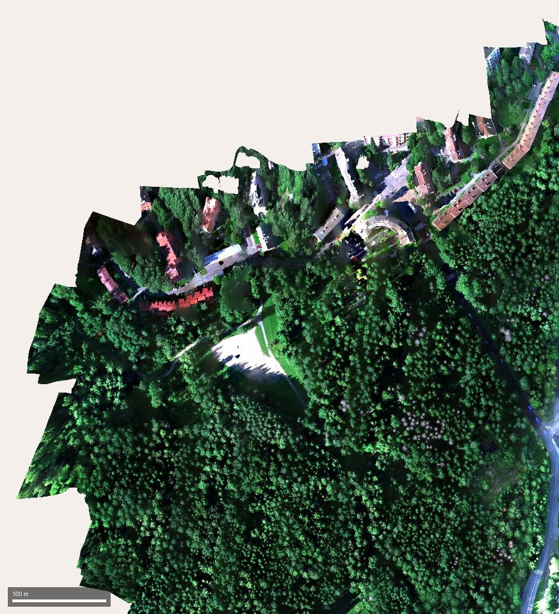

**Abb. 1 — Orthomosaik, Echtfarbendarstellung.** Fläche Männikkötie, Helsinki; 597 × 655 m, 8,7 cm Bodenauflösung, MicaSense RedEdge-M, September 2020. Der Bestand grenzt im Norden unmittelbar an Bebauung — für die Interpretation der Modellausgabe unten ist das der entscheidende Umstand.

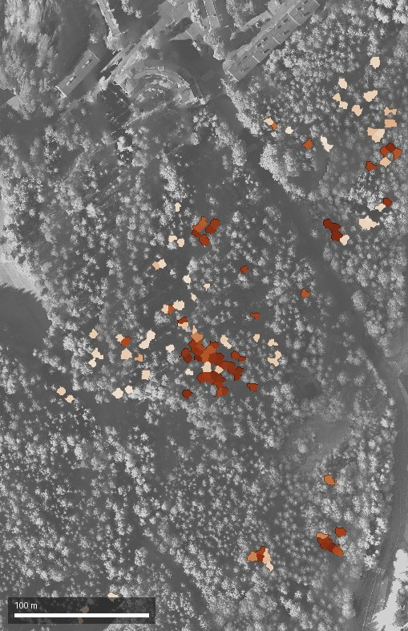

**Abb. 2 — Ergebnis auf Einzelbaumebene.** 131 Kronenpolygone, eingefärbt nach mittlerer Modellwahrscheinlichkeit. 63 davon überschreiten die Schwelle 0,5. Das ist das eigentliche Produkt der Kette: die pixelweise Ausgabe wird erst durch die Aggregation auf Kronen zu einer forstlich verwertbaren Aussage.

0,01,0

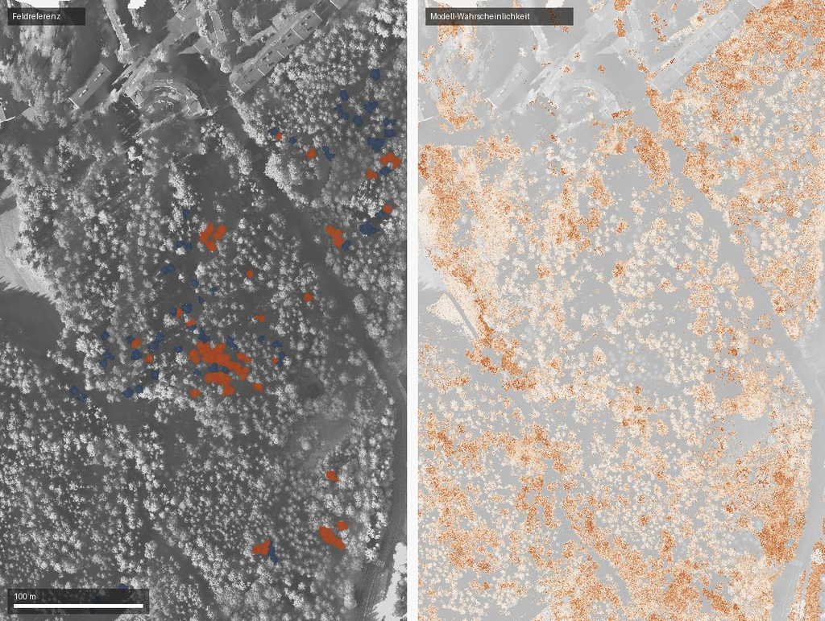

**Abb. 3 — Feldreferenz und pixelweise Modellausgabe.** Links die im Feld angesprochenen Kronen (rost = geschädigt, blau = vital), rechts die Wahrscheinlichkeit je Pixel innerhalb der Vegetationsmaske. Die pixelweise Ausgabe ist erwartungsgemäß verrauscht — genau deshalb erfolgt die Aggregation in Abb. 2.

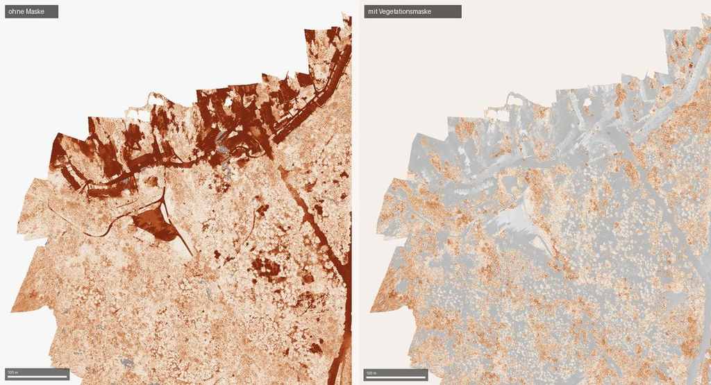

**Abb. 4 — Warum die Maske nicht optional ist.** Links die rohe Modellausgabe über die gesamte Fläche: die höchsten Wahrscheinlichkeiten liegen auf *Dächern und Asphalt*. Trainiert wurde ausschließlich auf Kronenpixeln — 1,08 % der Szene —, alles übrige ist Extrapolation außerhalb des Merkmalsraums. Rechts dieselbe Karte, begrenzt auf Vegetation.

**Quantifiziert.** Innerhalb der Vegetationsmaske liegt die mittlere Wahrscheinlichkeit bei **0,223** und 6,2 % der Pixel überschreiten 0,5. Außerhalb sind es **0,496** und 44,2 %. Ein Random Forest extrapoliert nicht, er antwortet auf jede Eingabe — auch auf Ziegeldächer. Eine Gültigkeitsmaske ist deshalb Teil des Produkts, nicht Kosmetik.

## Verarbeitungskette

01

Orthomosaik

5 Bänder, 8 cm GSD; Bandreihenfolge physikalisch geprüft

02

Merkmale

NIR + 7 Vegetationsindizes, pixelweise

03

Training

Random Forest, kronenweise CV

04

Karte

Wahrscheinlichkeit + Binärmaske

05

Einzelbaum

Aggregation auf Kronenpolygone

## Datengrundlage

| Merkmal | Validierungsdatensatz | Referenzstudie |
| --- | --- | --- |
| Gebiet | Männikkötie, Helsinki (FI) | Puszcza Niepołomicka (PL) |
| Sensor | MicaSense RedEdge-M | MicaSense RedEdge-M |
| Auflösung | 8 cm GSD | 7 cm GSD |
| Baumart | *Picea abies* | *Pinus sylvestris* |
| Zielgröße | Vitalitätsverlust (Borkenkäfer) | Mistelbefall |
| Referenz | 556 Kronen im Feld angesprochen | 2 917 Kronen, 58,6 % befallen |
| Labels offen? | ja, CC-BY-4.0 | nein |

Der Validierungsdatensatz wurde gewählt, weil er als einziger offen verfügbarer Datensatz alle Anforderungen gleichzeitig erfüllt: Nadelbaum, fünfbandiges Multispektral-Orthomosaik in Zentimeterauflösung, Kronenpolygone *und* binäre Feldansprache — bei praktisch identischem Sensor und Maßstab.

### Zur Bezugsgröße der Kronenauswertung

Die 131 ausgewerteten Kronen sind nicht alle Bäume der Fläche, sondern die im Feld angesprochenen. Die Geopackage-Datei enthält 556 Kronen aus vier Flugflächen; das Orthomosaik deckt mit Männikkötie genau eine davon ab, die übrigen 425 liegen außerhalb der Rasterausdehnung.

Innerhalb dieser Stichprobe weist die *Feldreferenz* 66 der 131 Kronen als geschädigt aus — 50,4 %, davon 64 stehend abgestorben (Verfärbungsgrad 5 bei fehlender Nadelverlustansprache). Der Datensatz wurde zur Untersuchung borkenkäferbedingten Absterbens erhoben; die Ansprache konzentriert sich entsprechend auf betroffene Bestandesteile und ist keine Zufallsstichprobe des Bestands. Dass das Modell 63 Kronen über die Schwelle 0,5 hebt, ist deshalb keine Übererkennung, sondern die Reproduktion einer im Feld belegten Rate.